# PSL: Multiple Linear Regression

### Week 2 Example (Fall 2025)

*This notebook is a Python conversion of the original R Markdown document.*

```python
import pandas as pd
import numpy as np
import scipy as sp
import matplotlib.pyplot as plt
import seaborn as sns

import statsmodels.api as sm
import statsmodels.formula.api as smf
from statsmodels.stats.outliers_influence import variance_inflation_factor
from statsmodels.graphics.gofplots import ProbPlot

from sklearn.model_selection import train_test_split
from sklearn.preprocessing import StandardScaler

sns.set()
```

## `Birthweight` Data Set Example

The `birthweight.csv` data set contains data from a study on the birth weight of **42** babies. The variables in the data set are the following:

- `ID`: Unique Identification number of a baby
- `Length`: Length of the baby at time of birth in cm ($X_1$)
- `Birthweight`: Weight of the baby at time of birth in kg ($Y$)
- `Headcirc`: Head circumference of the baby at time of birth in cm ($X_2$)
- `Gestation`: Completed weeks of gestation ($X_3$)
- `smoker`: Mother is/is not a smoker {0: No, 1: Yes} ($X_4$)
- `mage`: Mother's age at time of birth ($X_5$)
- `mnocig`: Mother's number of cigarettes smoked per day ($X_6$)
- `mheight`: Mother's height in cm ($X_7$)
- `mppwt`: Mother's pre-pregnancy weight ($X_8$)
- `fage`: Father's age at time of birth ($X_9$)
- `fedyrs`: Father's years of education ($X_{10}$)
- `fnocig`: Father's number of cigarettes smoked per day ($X_{11}$)
- `fheight`: Father's height ($X_{12}$)

```python
# load data
birthweight = pd.read_csv("Birthweight.csv")
print("Shape:", birthweight.shape)
birthweight.head()
```

```
Shape: (42, 14)
```

|  | ID | Length | Birthweight | Headcirc | Gestation | smoker | mage | mnocig | mheight | mppwt | fage | fedyrs | fnocig | fheight |
| --- | --- | --- | --- | --- | --- | --- | --- | --- | --- | --- | --- | --- | --- | --- |
| 0 | 1360 | 56 | 4.55 | 34 | 44 | 0 | 20 | 0 | 162 | 57 | 23 | 10 | 35 | 179 |
| 1 | 1016 | 53 | 4.32 | 36 | 40 | 0 | 19 | 0 | 171 | 62 | 19 | 12 | 0 | 183 |
| 2 | 462 | 58 | 4.10 | 39 | 41 | 0 | 35 | 0 | 172 | 58 | 31 | 16 | 25 | 185 |
| 3 | 1187 | 53 | 4.07 | 38 | 44 | 0 | 20 | 0 | 174 | 68 | 26 | 14 | 25 | 189 |
| 4 | 553 | 54 | 3.94 | 37 | 42 | 0 | 24 | 0 | 175 | 66 | 30 | 12 | 0 | 184 |

Since the `ID` variable is not of interest in our analysis, we won't use it in our analysis. For convenience can remove it from the data frame we are working with:

```python
birthweight = birthweight.drop('ID', axis=1)
```

### Fitting a Multiple Linear Regression

We start by fitting a linear regression model using all the predictors and we print the summary of the LS results:

```python
# statsmodels support R-style formula but not the period operator
# so we must construct the full formula manually
var_names = birthweight.columns.drop(['Birthweight'])
fml_full = 'Birthweight ~ ' + ' + '.join(x for x in var_names)
```

```python
birthweight_mlr_full = smf.ols(formula=fml_full, data=birthweight).fit()
birthweight_mlr_full.summary()
```

OLS Regression Results

| Dep. Variable: | Birthweight | R-squared: | 0.783 |
| --- | --- | --- | --- |
| Model: | OLS | Adj. R-squared: | 0.694 |
| Method: | Least Squares | F-statistic: | 8.742 |
| Date: | Tue, 02 Sep 2025 | Prob (F-statistic): | 1.01e-06 |
| Time: | 11:56:36 | Log-Likelihood: | -5.7803 |
| No. Observations: | 42 | AIC: | 37.56 |
| Df Residuals: | 29 | BIC: | 60.15 |
| Df Model: | 12 |  |  |
| Covariance Type: | nonrobust |  |  |

|  | coef | std err | t | P>\|t\| | [0.025 | 0.975] |
| --- | --- | --- | --- | --- | --- | --- |
| Intercept | -3.8123 | 2.080 | -1.833 | 0.077 | -8.067 | 0.442 |
| Length | 0.0342 | 0.031 | 1.086 | 0.287 | -0.030 | 0.098 |
| Headcirc | 0.0866 | 0.029 | 2.937 | 0.006 | 0.026 | 0.147 |
| Gestation | 0.0966 | 0.031 | 3.083 | 0.004 | 0.033 | 0.161 |
| smoker | -0.2439 | 0.169 | -1.447 | 0.159 | -0.589 | 0.101 |
| mage | -0.0190 | 0.019 | -1.025 | 0.314 | -0.057 | 0.019 |
| mnocig | 0.0011 | 0.007 | 0.155 | 0.878 | -0.013 | 0.015 |
| mheight | 0.0042 | 0.014 | 0.296 | 0.769 | -0.025 | 0.033 |
| mppwt | 0.0103 | 0.011 | 0.921 | 0.364 | -0.013 | 0.033 |
| fage | 0.0072 | 0.016 | 0.440 | 0.663 | -0.026 | 0.041 |
| fedyrs | 0.0032 | 0.031 | 0.104 | 0.918 | -0.060 | 0.066 |
| fnocig | 0.0034 | 0.004 | 0.858 | 0.398 | -0.005 | 0.012 |
| fheight | -0.0133 | 0.010 | -1.383 | 0.177 | -0.033 | 0.006 |

| Omnibus: | 5.590 | Durbin-Watson: | 1.680 |
| --- | --- | --- | --- |
| Prob(Omnibus): | 0.061 | Jarque-Bera (JB): | 3.108 |
| Skew: | 0.448 | Prob(JB): | 0.211 |
| Kurtosis: | 2.013 | Cond. No. | 1.07e+04 |

Notes:  
[1] Standard Errors assume that the covariance matrix of the errors is correctly specified.  
[2] The condition number is large, 1.07e+04. This might indicate that there are  
strong multicollinearity or other numerical problems.

If we want to check the objects returned by `smf.ols`:

```python
[x for x in dir(birthweight_mlr_full) if not x.startswith('_')]
```

```
['HC0_se',
 'HC1_se',
 'HC2_se',
 'HC3_se',
 'aic',
 'bic',
 'bse',
 'centered_tss',
 'compare_f_test',
 'compare_lm_test',
 'compare_lr_test',
 'condition_number',
 'conf_int',
 'conf_int_el',
 'cov_HC0',
 'cov_HC1',
 'cov_HC2',
 'cov_HC3',
 'cov_kwds',
 'cov_params',
 'cov_type',
 'df_model',
 'df_resid',
 'diagn',
 'eigenvals',
 'el_test',
 'ess',
 'f_pvalue',
 'f_test',
 'fittedvalues',
 'fvalue',
 'get_influence',
 'get_prediction',
 'get_robustcov_results',
 'info_criteria',
 'initialize',
 'k_constant',
 'llf',
 'load',
 'model',
```

[output cut: 12 more lines]

```
 'rsquared',
 'rsquared_adj',
 'save',
 'scale',
 'ssr',
 'summary',
 'summary2',
 't_test',
 't_test_pairwise',
 'tvalues',
 'uncentered_tss',
 'use_t',
 'wald_test',
 'wald_test_terms',
 'wresid']
```

The design matrix in this example can be extracted using:

```python
# The design matrix (including intercept) is stored in the .model.exog attribute
design_birthweight = birthweight_mlr_full.model.exog
```

If we want to extract the Regression coefficients including the intercept, i.e. $\hat{\beta}$, we have:

```python
# The coefficients are stored in the .params attribute
birthweight_mlr_full.params
```

```
Intercept   -3.812311
Length       0.034152
Headcirc     0.086594
Gestation    0.096565
smoker      -0.243895
mage        -0.019004
mnocig       0.001064
mheight      0.004187
mppwt        0.010346
fage         0.007187
fedyrs       0.003220
fnocig       0.003445
fheight     -0.013293
dtype: float64
```

The fitted values and residuals are obtained by:

```python
full_model_residuals = birthweight_mlr_full.resid
full_model_fitted = birthweight_mlr_full.fittedvalues
```

Check the calculation for Residual standard error and Multiple R-squared in the summary output.

The residuals $\mathbf{r}$ are used to estimate the *error variance*: $$\hat{\sigma}^2 = \frac{1}{n-p-1}\sum_i r_i^2 = \frac{\text{RSS}}{n-p-1}$$

To obtain an estimator for $\hat{\sigma}$, we can either use the formula (from the notes):

```python
n = birthweight.shape[0]
p = birthweight.shape[1] - 1  # Number of predictors (excluding response)
rse = np.sqrt(np.sum(full_model_residuals ** 2) / (n - p - 1))
print(f"Manual RSE calculation: {rse:.6f}")
```

```
Manual RSE calculation: 0.334163
```

or we can extract it from the `ols` object:

```python
# The model's 'scale' attribute is the estimated error variance (sigma-squared)
sigma_from_model = np.sqrt(birthweight_mlr_full.scale)
print(f"RSE from model (sqrt of scale): {sigma_from_model:.6f}")
```

```
RSE from model (sqrt of scale): 0.334163
```

The coefficient of determination computes as: $$ \frac{\sum_i (\hat{y}_i - \bar{y})^2}{\sum_i (y_i - \bar{y})^2} = 1 - \frac{\text{RSS}}{\text{TSS}}$$ We can extract $R^2$ from the output or compute it:

```python
print(f"R-squared from model: {birthweight_mlr_full.rsquared:.6f}")

rss = np.sum(full_model_residuals ** 2)
tss = np.sum((birthweight['Birthweight'] -
             birthweight['Birthweight'].mean()) ** 2)
r_squared_manual1 = 1 - (rss / tss)
r_squared_manual2 = 1 - np.var(full_model_residuals) / \
    np.var(birthweight['Birthweight'])

print(
    f"Manual R-squared calculations: {r_squared_manual1:.6f} and {r_squared_manual2:.6f}")
```

```
R-squared from model: 0.783425
Manual R-squared calculations: 0.783425 and 0.783425
```

#### Invariance of $R^2$ & Fitted Values

We can also check the invariance property of $R^2$ by rescaling one of the variables:

```python
# Center the Length variable
birthweight_new = birthweight.copy()
birthweight_new['Length_centered'] = birthweight_new['Length'] - \
    birthweight_new['Length'].mean()

# Model with original `Length` (same as birthweight_mlr_full)
model_orig = smf.ols(fml_full, data=birthweight).fit()

# Model with centered `Length`
# We create a formula that includes all columns from birthweight_new except 'Length'
predictors_centered = birthweight_new.columns.drop(['Birthweight', 'Length'])
fml_centered = 'Birthweight ~ ' + ' + '.join(predictors_centered)
model_centered = smf.ols(fml_centered, data=birthweight_new).fit()

print(f"R-squared with original `Length`: {model_orig.rsquared:.6f}")
print(f"R-squared with centered `Length`: {model_centered.rsquared:.6f}")
```

```
R-squared with original `Length`: 0.783425
R-squared with centered `Length`: 0.783425
```

If we want, we can also check that the fitted values from both models are identical:

```python
fit_diff = np.sum(model_orig.fittedvalues - model_centered.fittedvalues)
print(f"Sum of differences in fitted values: {fit_diff}")
```

```
Sum of differences in fitted values: 6.945555242054979e-13
```

Note that the difference is not exactly 0, since there are rounding errors that accumulated when the various functions are applied.

#### $R^2$ and $\text{RSS}$ behavior when adding more $X$'s

We can also visualize how the $R^2$ and $\text{RSS}$ change as a function of the number of variables in the model to observe that adding a new predictor, even if it is randomly generated and has nothing to do with $Y$ will decrease $\text{RSS}$ and therefore increase $R^2$.

So, start with the null model that contains only the intercept and then we add variables one at a time, keeping the $R^2$ and $\text{RSS}$ that we will plot in the end. We will also randomly generate a new variable `randomvar` to illustrate that even an unrelevant variable has an effect on both $R^2$ and $\text{RSS}$ :

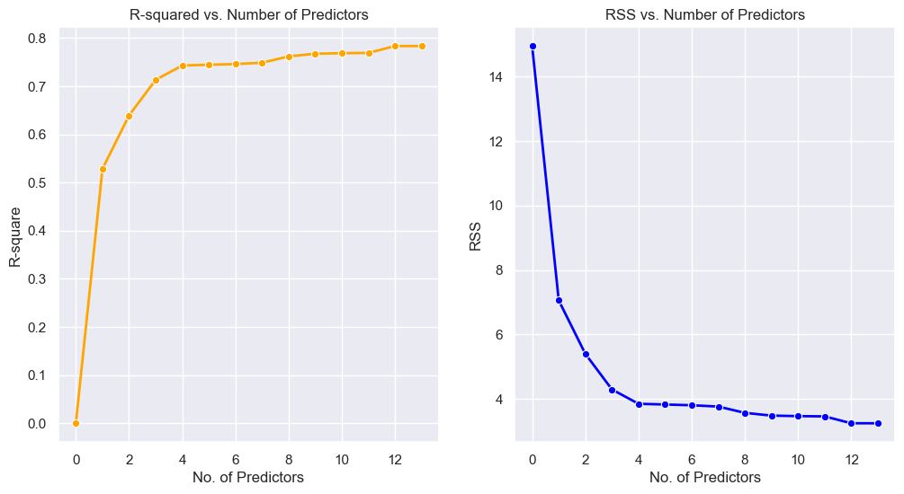

```python
birthweight_new = birthweight.copy()
birthweight_new['randomvar'] = np.random.normal(size=birthweight_new.shape[0])
predictors = birthweight_new.columns.drop(['Birthweight']).tolist()

rsq = []
rss = []

# Model with only intercept
intercept_model = smf.ols('Birthweight ~ 1', data=birthweight_new).fit()
rsq.append(intercept_model.rsquared)
rss.append(intercept_model.ssr)  # ssr is Sum of Squared Residuals

# Sequentially add predictors
for i in range(len(predictors)):
    current_predictors = predictors[:(i + 1)]
    formula = 'Birthweight ~ ' + ' + '.join(current_predictors)
    model = smf.ols(formula, data=birthweight_new).fit()
    rsq.append(model.rsquared)
    rss.append(model.ssr)

fig, (ax1, ax2) = plt.subplots(1, 2, figsize=(12, 6))

sns.lineplot(x=range(len(rsq)), y=rsq, lw=2, color='orange', marker='o', ax=ax1)
ax1.set_xlabel("No. of Predictors")
ax1.set_ylabel("R-square")
ax1.set_title("R-squared vs. Number of Predictors")

sns.lineplot(x=range(len(rss)), y=rss, lw=2, color='blue', marker='o', ax=ax2)
ax2.set_xlabel("No. of Predictors")
ax2.set_ylabel("RSS")
ax2.set_title("RSS vs. Number of Predictors")

plt.show()
```

This is to illustrate why $R^2$ and $\text{RSS}$ are not good metrics when it comes to model selection. They are useful, because they helps us understand the quality of the model or $\text{RSS}$ is a key ingredient in constructing hypothesis tests, but they are never used for model selection.

### Rank Deficiency

We have rank deficiency when $\mathbf{X}$ is not of full rank which leads to the $(\mathbf{X}^\top\mathbf{X})$ matrix not being invertible.

Here we illustrate a scenario where it is easy to identify the cause of the problem.

```python
# Create a new variable: the average height of both parents
birthweight_new = birthweight.copy()
birthweight_new['aveheight'] = (
    birthweight_new['mheight'] + birthweight_new['fheight']) / 2
var_names = birthweight_new.columns.drop(['Birthweight'])
fml_full_new = "Birthweight" + "~" + "+".join(x for x in var_names)

# Regress birthweight against all predictors
model_rankdef = smf.ols(fml_full_new, data=birthweight_new).fit(method='qr')
model_rankdef.summary()
```

```
/Users/alexandrachronopoulou/Desktop/STAT 542/Lecture Slides/Week 2 - Linear Regression/Week 2 - R Code/.venv/lib/python3.13/site-packages/statsmodels/regression/linear_model.py:1884: RuntimeWarning: invalid value encountered in sqrt
  return np.sqrt(np.diag(self.cov_params()))
```

OLS Regression Results

| Dep. Variable: | Birthweight | R-squared: | 0.747 |
| --- | --- | --- | --- |
| Model: | OLS | Adj. R-squared: | 0.642 |
| Method: | Least Squares | F-statistic: | 7.126 |
| Date: | Tue, 02 Sep 2025 | Prob (F-statistic): | 7.85e-06 |
| Time: | 11:57:09 | Log-Likelihood: | -9.0658 |
| No. Observations: | 42 | AIC: | 44.13 |
| Df Residuals: | 29 | BIC: | 66.72 |
| Df Model: | 12 |  |  |
| Covariance Type: | nonrobust |  |  |

|  | coef | std err | t | P>\|t\| | [0.025 | 0.975] |
| --- | --- | --- | --- | --- | --- | --- |
| Intercept | -4.7031 | 2.249 | -2.091 | 0.045 | -9.304 | -0.103 |
| Length | 0.0267 | 0.034 | 0.785 | 0.439 | -0.043 | 0.096 |
| Headcirc | 0.0934 | 0.032 | 2.930 | 0.007 | 0.028 | 0.159 |
| Gestation | 0.0827 | 0.034 | 2.441 | 0.021 | 0.013 | 0.152 |
| smoker | -0.1953 | 0.182 | -1.072 | 0.293 | -0.568 | 0.177 |
| mage | -0.0226 | 0.020 | -1.130 | 0.268 | -0.064 | 0.018 |
| mnocig | 0.0007 | 0.007 | 0.100 | 0.921 | -0.014 | 0.016 |
| mheight | 1.471e+12 | nan | nan | nan | nan | nan |
| mppwt | 0.0084 | 0.012 | 0.689 | 0.496 | -0.016 | 0.033 |
| fage | 0.0132 | 0.018 | 0.746 | 0.462 | -0.023 | 0.049 |
| fedyrs | 0.0131 | 0.033 | 0.390 | 0.699 | -0.055 | 0.081 |
| fnocig | 0.0013 | 0.004 | 0.304 | 0.763 | -0.008 | 0.010 |
| fheight | 1.471e+12 | nan | nan | nan | nan | nan |
| aveheight | -2.943e+12 | nan | nan | nan | nan | nan |

| Omnibus: | 3.294 | Durbin-Watson: | 1.338 |
| --- | --- | --- | --- |
| Prob(Omnibus): | 0.193 | Jarque-Bera (JB): | 3.026 |
| Skew: | 0.590 | Prob(JB): | 0.220 |
| Kurtosis: | 2.422 | Cond. No. | 1.40e+16 |

Notes:  
[1] Standard Errors assume that the covariance matrix of the errors is correctly specified.  
[2] The smallest eigenvalue is 2.16e-26. This might indicate that there are  
strong multicollinearity problems or that the design matrix is singular.

This issue can be easily fixed, by removing one or more variables. Which variable will be removed depends on the context. For example, we need to (conceptually) answer the question on whether we prefer to have the aveheight or each parent’s height individually.

A harder issue to resolve is when two predictors are not exaclty linearly dependent, but approximately - this means that they are highly correlated, but not an exact function of one another. This is more challenging to deal with and we will discuss it later.

### Test for the Significance of Predictors

We use the partial $F$ test $$F=\frac{\bigl(RSS_0 - RSS_{\alpha}\bigr)/(p_{\alpha} - p_0)}{RSS_{\alpha}/ \bigl(n-p_{\alpha} \bigr)}\, \sim \, F_{p_{\alpha} - p_0, n-p_{\alpha}}$$ to compare the full model with all available predictors versus the model that exclude father-related variables. That is, the hypothesis test is formulated as $$\begin{cases} &H_0: Y \sim 1+ \beta_{1} X_{1} + \ldots + \beta_{8}X_{8} \\ & H_{\alpha}: Y \sim 1+ \beta_1 X_1 + \ldots + \beta_{8}X_{8}+ \ldots + \beta_{12} X_{12} \end{cases} $$

```python
# Full Model was fitted before and is stored in birthweight_mlr_full

# Reduced Model (without father-related variables)
reduced_formula1 = 'Birthweight ~ Length + Headcirc + Gestation + smoker + mage + mnocig + mheight + mppwt'
birthweight_mlr_reduced1 = smf.ols(reduced_formula1, data=birthweight).fit()
```

We can use one function to perform the test:

```python
anova_results = sm.stats.anova_lm(
    birthweight_mlr_reduced1, birthweight_mlr_full)
anova_results
```

|  | df_resid | ssr | df_diff | ss_diff | F | Pr(>F) |
| --- | --- | --- | --- | --- | --- | --- |
| 0 | 33.0 | 3.560996 | 0.0 | NaN | NaN | NaN |
| 1 | 29.0 | 3.238285 | 4.0 | 0.322711 | 0.722498 | 0.583652 |

The $F$ statistic value is 0.7225, and the corresponding $p$-value is 0.5837 which means that we fail to reject the null and conclude that the model under the $H_0$ is preferred. In other words, we prefer the smaller model which implies that the father-related predictors can be removed from the model.

We can also build the $F$ statistic, by extracting all necessary components:

```python
RSS0 = birthweight_mlr_reduced1.ssr
RSSalpha = birthweight_mlr_full.ssr
print(f"RSS0 (Reduced): {RSS0:.4f}")
print(f"RSSalpha (Full): {RSSalpha:.4f}")

p0 = len(birthweight_mlr_reduced1.params)
palpha = len(birthweight_mlr_full.params)
n = birthweight.shape[0]

# Partial F test
F_manual = ((RSS0 - RSSalpha) / (palpha - p0)) / (RSSalpha / (n - palpha))
print(f"Manual F-statistic: {F_manual:.4f}")

# Critical value to compare with the F statistic.
alpha = 0.05
dfn = palpha - p0
dfd = n - palpha
critical_value = sp.stats.f.ppf(1 - alpha, dfn=dfn, dfd=dfd)
print(f"Critical F-value at alpha={alpha}: {critical_value:.4f}")
```

```
RSS0 (Reduced): 3.5610
RSSalpha (Full): 3.2383
Manual F-statistic: 0.7225
Critical F-value at alpha=0.05: 2.7014
```

the conclusion is the same since $F < F_{crit}$.

#### Testing for a Single $\beta_j$

Let's test for the significance of variable `Length` ($X_1$), i.e. $$\begin{cases} &H_0: Y \sim 1 + \qquad \quad \beta_2 X_2 + \ldots + \beta_{12}X_{12} \\ & H_{\alpha}: Y \sim 1+ \beta_1 X_1+ \beta_2 X_2 + \ldots + \beta_{12} X_{12} \\ \end{cases} $$ We fit the full model and then compare by means of the partial $F$ test:

```python
# Full Model was fitted before and is stored in birthweight_mlr_full

# Reduced Model (without 'Length')
reduced_formula2 = 'Birthweight ~ Headcirc + Gestation + smoker + mage + mnocig + mheight + mppwt + fage + fedyrs + fnocig + fheight'
birthweight_mlr_reduced2 = smf.ols(reduced_formula2, data=birthweight).fit()

# Partial F test
anova_single_var = sm.stats.anova_lm(
    birthweight_mlr_reduced2, birthweight_mlr_full)
anova_single_var
```

|  | df_resid | ssr | df_diff | ss_diff | F | Pr(>F) |
| --- | --- | --- | --- | --- | --- | --- |
| 0 | 30.0 | 3.369906 | 0.0 | NaN | NaN | NaN |
| 1 | 29.0 | 3.238285 | 1.0 | 0.131622 | 1.178721 | 0.286559 |

```python
# Compare the $F$ value above with the square of the $t$ test
# for the length variable in the output below:
birthweight_mlr_full.summary()
```

OLS Regression Results

| Dep. Variable: | Birthweight | R-squared: | 0.783 |
| --- | --- | --- | --- |
| Model: | OLS | Adj. R-squared: | 0.694 |
| Method: | Least Squares | F-statistic: | 8.742 |
| Date: | Tue, 02 Sep 2025 | Prob (F-statistic): | 1.01e-06 |
| Time: | 11:57:31 | Log-Likelihood: | -5.7803 |
| No. Observations: | 42 | AIC: | 37.56 |
| Df Residuals: | 29 | BIC: | 60.15 |
| Df Model: | 12 |  |  |
| Covariance Type: | nonrobust |  |  |

|  | coef | std err | t | P>\|t\| | [0.025 | 0.975] |
| --- | --- | --- | --- | --- | --- | --- |
| Intercept | -3.8123 | 2.080 | -1.833 | 0.077 | -8.067 | 0.442 |
| Length | 0.0342 | 0.031 | 1.086 | 0.287 | -0.030 | 0.098 |
| Headcirc | 0.0866 | 0.029 | 2.937 | 0.006 | 0.026 | 0.147 |
| Gestation | 0.0966 | 0.031 | 3.083 | 0.004 | 0.033 | 0.161 |
| smoker | -0.2439 | 0.169 | -1.447 | 0.159 | -0.589 | 0.101 |
| mage | -0.0190 | 0.019 | -1.025 | 0.314 | -0.057 | 0.019 |
| mnocig | 0.0011 | 0.007 | 0.155 | 0.878 | -0.013 | 0.015 |
| mheight | 0.0042 | 0.014 | 0.296 | 0.769 | -0.025 | 0.033 |
| mppwt | 0.0103 | 0.011 | 0.921 | 0.364 | -0.013 | 0.033 |
| fage | 0.0072 | 0.016 | 0.440 | 0.663 | -0.026 | 0.041 |
| fedyrs | 0.0032 | 0.031 | 0.104 | 0.918 | -0.060 | 0.066 |
| fnocig | 0.0034 | 0.004 | 0.858 | 0.398 | -0.005 | 0.012 |
| fheight | -0.0133 | 0.010 | -1.383 | 0.177 | -0.033 | 0.006 |

| Omnibus: | 5.590 | Durbin-Watson: | 1.680 |
| --- | --- | --- | --- |
| Prob(Omnibus): | 0.061 | Jarque-Bera (JB): | 3.108 |
| Skew: | 0.448 | Prob(JB): | 0.211 |
| Kurtosis: | 2.013 | Cond. No. | 1.07e+04 |

Notes:  
[1] Standard Errors assume that the covariance matrix of the errors is correctly specified.  
[2] The condition number is large, 1.07e+04. This might indicate that there are  
strong multicollinearity or other numerical problems.

```python
# The square of the t-value is obtained by:
t_value_length = birthweight_mlr_full.tvalues['Length']
f_from_t_sq = t_value_length ** 2
f_from_t_sq
```

```
np.float64(1.1787209295796566)
```

#### Testing for all the predictors

The $F$ test statistic and corresponding $p$-value in the `summary` output correspond to the following hypothesis: $$\begin{cases} &H_0: Y \sim 1 \\ & H_{\alpha}: Y \sim 1+ \beta_1 X_1 + \ldots + \beta_p X_p \\ \end{cases} $$ which is the so-called **overall $F$ test**.

```python
print(f"Model degrees of freedom: {birthweight_mlr_full.df_model}")
print(f"Residual degrees of freedom.: {birthweight_mlr_full.df_resid}")
print(f"Overall F-statistic: {birthweight_mlr_full.fvalue:.4f}")
print(f"Overall F p-value: {birthweight_mlr_full.f_pvalue:.4e}")
```

```
Model degrees of freedom: 12.0
Residual degrees of freedom.: 29.0
Overall F-statistic: 8.7419
Overall F p-value: 1.0111e-06
```

In this case, the $F$ value is equal to 8.74 and it follows an $F_{12, 29}$ distribution.The corresponding $p$-value is equal to `1.0111e-06` which is much less than $\alpha=0.05$. This implies that we reject the null and conclude that the model with all the predictors is more adequate compared to the intercept-only model.

### Categorical Variables

In the `birthweight` data set we only have binary variables, so for illustration purposes, we will create a new categorical variable, `mage.group` with 3 levels: $a$=below 20, $b$=20-30, and $c$=above 30:

```python
birthweight_new = birthweight.copy()

conditions = [
    (birthweight_new['mage'] < 20),
    (birthweight_new['mage'] > 30)
]
choices = ['a', 'c']
birthweight_new['mage_group'] = np.select(conditions, choices, default='b')

# Let's fit the model with the age group variable and look at the design matrix:
formula_cat = 'Birthweight ~ ' + \
    ' + '.join(birthweight_new.columns.drop(['Birthweight', 'mage']))
birthweight_mlr_categorical = smf.ols(formula_cat, data=birthweight_new).fit()

# The design matrix shows the dummy variables created for 'mage_group'
design_matrix_cat = pd.DataFrame(
    birthweight_mlr_categorical.model.exog,
    columns=birthweight_mlr_categorical.model.exog_names
)
design_matrix_cat
```

|  | Intercept | mage_group[T.b] | mage_group[T.c] | Length | Headcirc | Gestation | smoker | mnocig | mheight | mppwt | fage | fedyrs | fnocig | fheight |
| --- | --- | --- | --- | --- | --- | --- | --- | --- | --- | --- | --- | --- | --- | --- |
| 0 | 1.0 | 1.0 | 0.0 | 56.0 | 34.0 | 44.0 | 0.0 | 0.0 | 162.0 | 57.0 | 23.0 | 10.0 | 35.0 | 179.0 |
| 1 | 1.0 | 0.0 | 0.0 | 53.0 | 36.0 | 40.0 | 0.0 | 0.0 | 171.0 | 62.0 | 19.0 | 12.0 | 0.0 | 183.0 |
| 2 | 1.0 | 0.0 | 1.0 | 58.0 | 39.0 | 41.0 | 0.0 | 0.0 | 172.0 | 58.0 | 31.0 | 16.0 | 25.0 | 185.0 |
| 3 | 1.0 | 1.0 | 0.0 | 53.0 | 38.0 | 44.0 | 0.0 | 0.0 | 174.0 | 68.0 | 26.0 | 14.0 | 25.0 | 189.0 |
| 4 | 1.0 | 1.0 | 0.0 | 54.0 | 37.0 | 42.0 | 0.0 | 0.0 | 175.0 | 66.0 | 30.0 | 12.0 | 0.0 | 184.0 |
| 5 | 1.0 | 1.0 | 0.0 | 51.0 | 38.0 | 38.0 | 0.0 | 0.0 | 165.0 | 61.0 | 31.0 | 16.0 | 0.0 | 180.0 |
| 6 | 1.0 | 1.0 | 0.0 | 52.0 | 34.0 | 40.0 | 0.0 | 0.0 | 157.0 | 50.0 | 31.0 | 16.0 | 0.0 | 173.0 |
| 7 | 1.0 | 1.0 | 0.0 | 53.0 | 33.0 | 42.0 | 0.0 | 0.0 | 165.0 | 61.0 | 21.0 | 10.0 | 25.0 | 185.0 |
| 8 | 1.0 | 0.0 | 0.0 | 54.0 | 38.0 | 38.0 | 0.0 | 0.0 | 172.0 | 50.0 | 20.0 | 12.0 | 7.0 | 172.0 |
| 9 | 1.0 | 1.0 | 0.0 | 50.0 | 35.0 | 38.0 | 0.0 | 0.0 | 157.0 | 48.0 | 22.0 | 14.0 | 0.0 | 179.0 |
| 10 | 1.0 | 1.0 | 0.0 | 53.0 | 33.0 | 41.0 | 0.0 | 0.0 | 164.0 | 62.0 | 37.0 | 14.0 | 0.0 | 170.0 |
| 11 | 1.0 | 1.0 | 0.0 | 51.0 | 36.0 | 40.0 | 0.0 | 0.0 | 168.0 | 53.0 | 29.0 | 16.0 | 0.0 | 181.0 |
| 12 | 1.0 | 0.0 | 1.0 | 52.0 | 36.0 | 38.0 | 0.0 | 0.0 | 164.0 | 57.0 | 35.0 | 16.0 | 0.0 | 183.0 |
| 13 | 1.0 | 1.0 | 0.0 | 53.0 | 33.0 | 41.0 | 0.0 | 0.0 | 155.0 | 55.0 | 25.0 | 14.0 | 25.0 | 183.0 |
| 14 | 1.0 | 1.0 | 0.0 | 53.0 | 34.0 | 40.0 | 0.0 | 0.0 | 167.0 | 60.0 | 30.0 | 16.0 | 25.0 | 182.0 |
| 15 | 1.0 | 1.0 | 0.0 | 48.0 | 33.0 | 37.0 | 0.0 | 0.0 | 158.0 | 54.0 | 39.0 | 10.0 | 0.0 | 171.0 |
| 16 | 1.0 | 1.0 | 0.0 | 48.0 | 35.0 | 39.0 | 0.0 | 0.0 | 162.0 | 62.0 | 27.0 | 14.0 | 0.0 | 178.0 |
| 17 | 1.0 | 1.0 | 0.0 | 48.0 | 33.0 | 34.0 | 0.0 | 0.0 | 167.0 | 64.0 | 25.0 | 12.0 | 25.0 | 175.0 |
| 18 | 1.0 | 0.0 | 0.0 | 53.0 | 34.0 | 39.0 | 0.0 | 0.0 | 165.0 | 57.0 | 23.0 | 14.0 | 2.0 | 193.0 |
| 19 | 1.0 | 1.0 | 0.0 | 43.0 | 32.0 | 33.0 | 0.0 | 0.0 | 149.0 | 45.0 | 26.0 | 16.0 | 0.0 | 169.0 |
| 20 | 1.0 | 1.0 | 0.0 | 53.0 | 38.0 | 40.0 | 1.0 | 2.0 | 170.0 | 59.0 | 24.0 | 12.0 | 12.0 | 185.0 |
| 21 | 1.0 | 1.0 | 0.0 | 51.0 | 33.0 | 41.0 | 1.0 | 7.0 | 160.0 | 53.0 | 24.0 | 16.0 | 12.0 | 176.0 |
| 22 | 1.0 | 0.0 | 0.0 | 50.0 | 30.0 | 37.0 | 1.0 | 7.0 | 165.0 | 60.0 | 20.0 | 14.0 | 0.0 | 183.0 |
| 23 | 1.0 | 1.0 | 0.0 | 50.0 | 35.0 | 39.0 | 1.0 | 7.0 | 159.0 | 52.0 | 23.0 | 14.0 | 25.0 | 200.0 |
| 24 | 1.0 | 1.0 | 0.0 | 48.0 | 30.0 | 37.0 | 1.0 | 7.0 | 163.0 | 47.0 | 20.0 | 10.0 | 35.0 | 185.0 |
| 25 | 1.0 | 0.0 | 1.0 | 46.0 | 32.0 | 35.0 | 1.0 | 7.0 | 166.0 | 57.0 | 37.0 | 14.0 | 25.0 | 173.0 |
| 26 | 1.0 | 1.0 | 0.0 | 48.0 | 30.0 | 33.0 | 1.0 | 7.0 | 161.0 | 50.0 | 20.0 | 10.0 | 35.0 | 180.0 |
| 27 | 1.0 | 0.0 | 1.0 | 58.0 | 39.0 | 41.0 | 1.0 | 12.0 | 173.0 | 70.0 | 38.0 | 14.0 | 25.0 | 180.0 |
| 28 | 1.0 | 0.0 | 1.0 | 53.0 | 34.0 | 40.0 | 1.0 | 12.0 | 163.0 | 49.0 | 41.0 | 12.0 | 50.0 | 191.0 |
| 29 | 1.0 | 1.0 | 0.0 | 49.0 | 36.0 | 40.0 | 1.0 | 12.0 | 152.0 | 48.0 | 37.0 | 12.0 | 25.0 | 170.0 |
| 30 | 1.0 | 1.0 | 0.0 | 52.0 | 35.0 | 38.0 | 1.0 | 12.0 | 165.0 | 64.0 | 38.0 | 14.0 | 50.0 | 180.0 |
| 31 | 1.0 | 1.0 | 0.0 | 51.0 | 38.0 | 39.0 | 1.0 | 17.0 | 157.0 | 48.0 | 32.0 | 12.0 | 25.0 | 169.0 |
| 32 | 1.0 | 1.0 | 0.0 | 50.0 | 33.0 | 39.0 | 1.0 | 17.0 | 156.0 | 53.0 | 24.0 | 12.0 | 7.0 | 179.0 |
| 33 | 1.0 | 1.0 | 0.0 | 50.0 | 33.0 | 45.0 | 1.0 | 25.0 | 163.0 | 54.0 | 30.0 | 16.0 | 0.0 | 183.0 |
| 34 | 1.0 | 1.0 | 0.0 | 52.0 | 36.0 | 39.0 | 1.0 | 25.0 | 170.0 | 78.0 | 40.0 | 16.0 | 50.0 | 178.0 |
| 35 | 1.0 | 0.0 | 1.0 | 53.0 | 37.0 | 41.0 | 1.0 | 25.0 | 161.0 | 66.0 | 46.0 | 16.0 | 0.0 | 175.0 |
| 36 | 1.0 | 1.0 | 0.0 | 52.0 | 37.0 | 40.0 | 1.0 | 25.0 | 170.0 | 62.0 | 30.0 | 10.0 | 25.0 | 181.0 |
| 37 | 1.0 | 1.0 | 0.0 | 52.0 | 33.0 | 39.0 | 1.0 | 25.0 | 181.0 | 69.0 | 23.0 | 16.0 | 2.0 | 181.0 |
| 38 | 1.0 | 0.0 | 1.0 | 49.0 | 34.0 | 38.0 | 1.0 | 25.0 | 162.0 | 57.0 | 32.0 | 16.0 | 50.0 | 194.0 |
| 39 | 1.0 | 1.0 | 0.0 | 53.0 | 34.0 | 41.0 | 1.0 | 35.0 | 163.0 | 51.0 | 31.0 | 16.0 | 25.0 | 185.0 |
| 40 | 1.0 | 1.0 | 0.0 | 47.0 | 33.0 | 35.0 | 1.0 | 35.0 | 170.0 | 57.0 | 23.0 | 12.0 | 50.0 | 186.0 |
| 41 | 1.0 | 0.0 | 1.0 | 53.0 | 32.0 | 40.0 | 1.0 | 50.0 | 168.0 | 61.0 | 31.0 | 16.0 | 0.0 | 173.0 |

When fitting the regression model, `statsmodels` automatically converted the factor to the appropriate number of indicator/dummy variables which were included in the design matrix. We observe that level $a$ is the baseline (it doesn't have its own column) and the two generated columns are for levels $b$ and $c$.

In general, the reference level can be changed as well as the coding. Those changes will affect the estimated $\beta$ coefficients, but they will not affect the fitted or predicted values.

### Mean Response Estimation & Prediction

In practice, we have target values for which we need to estimate the mean response of values for which we want to do prediction. Since this is not the case here, in order to illustrate both methods, we use as inputs the mean value of every predictor.

```python
# The response variable is 'Birthweight', so we drop it from the mean calculation
mean_values = birthweight.drop('Birthweight', axis=1).mean()
```

Now, we create the $X$ `DataFrame` to use as an input in the `predict()` function:

```python
x_new = pd.DataFrame(mean_values).T
```

Using the `predict` function we have:

```python
# Use the predict function
prediction = birthweight_mlr_full.predict(x_new)
prediction
```

```
0    3.312857
dtype: float64
```

### Training vs. Testing Error

In this example, and in linear regression models, as we introduce more variables, training error (measured by $\text{RSS}$ or $\text{MSE}$) consistently decreases. However, this reduction in training error does not guarantee a corresponding decrease in test error, which measures prediction accuracy on independent test data. To demonstrate this, we randomly split our dataset into $60\%$ training and $40\%$ test portions, progressively adding predictors.

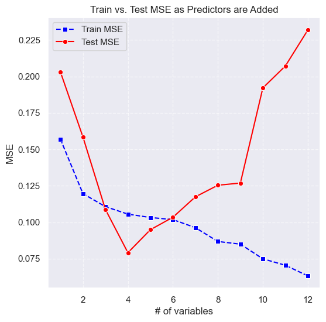

```python
# Using sklearn's train_test_split is the standard Python approach
X = birthweight.drop('Birthweight', axis=1)
y = birthweight['Birthweight']
p = X.shape[1]

X_train, X_test, y_train, y_test = train_test_split(X, y, test_size=0.4, random_state=42)

train_data = pd.concat([X_train, y_train], axis=1)
test_data = pd.concat([X_test, y_test], axis=1)

train_mse = []
test_mse = []
predictor_cols = X.columns.tolist()

for i in range(p):
    current_predictors = predictor_cols[:i + 1]
    formula = 'Birthweight ~ ' + ' + '.join(current_predictors)

    # Fit model on training data
    model = smf.ols(formula, data=train_data).fit()

    # Predict and calculate MSE for training set
    train_pred = model.predict(X_train)
    train_mse.append(np.mean((y_train - train_pred) ** 2))

    # Predict and calculate MSE for test set
    test_pred = model.predict(X_test)
    test_mse.append(np.mean((y_test - test_pred) ** 2))

# Plotting Train vs. Test MSE
plt.figure(figsize=(6, 6))
sns.lineplot(x=range(1, len(predictor_cols) + 1), y=train_mse,
         linestyle='--', marker='s', color='blue', label='Train MSE')
sns.lineplot(x=range(1, len(predictor_cols) + 1), y=test_mse,
         linestyle='-', marker='o' \
         '', color='red', label='Test MSE')
plt.xlabel("# of variables")
plt.ylabel("MSE")
plt.title("Train vs. Test MSE as Predictors are Added")
plt.legend()
plt.grid(True, linestyle='--', alpha=0.6)
plt.show()
```

In general, we expect that in each iteration, the blue line (representing the training error) consistently exhibits a monotonically decreasing trend, signifying the reduction of training error as more predictors are incorporated. On the other hand, the red line’s (testing error) trajectory may not uniformly decrease.

### Test for Outliers

```python
# We work with the full model again.
n = birthweight.shape[0]
p = birthweight.shape[1]
```

We first compute the studentized residuals using the `get_influence()` function and the Bonferroni critical value using Student’s distribution:

```python
# Computing Studentized Residuals
influence = birthweight_mlr_full.get_influence()
studentized_residuals = influence.resid_studentized_internal

# Critical value WITH Bonferroni correction
alpha = 0.05
bonferroni_cv = sp.stats.t.ppf(alpha / (2 * n), df=n - p - 1)
print(f"Bonferroni critical value: {bonferroni_cv:.4f}")
```

```
Bonferroni critical value: -3.6076
```

Now, we need to find which (if any) studentized residuals exceed the Bonferroni critical value:

```python
# Sorting the residuals in descending order to find outliers (if any)
abs_studentized_resid = np.abs(studentized_residuals)
sorted_resid = np.sort(abs_studentized_resid)[::-1]
print("\nTop 10 absolute studentized residuals:")
print(sorted_resid[:10])

# Find outliers
outliers = sorted_resid[sorted_resid > np.abs(bonferroni_cv)]
print(f"\nNumber of outliers (residuals > critical value): {len(outliers)}")
```

```
Top 10 absolute studentized residuals:
[1.96073359 1.81163213 1.76071978 1.63166956 1.59918995 1.57035592
 1.4101976  1.38820038 1.32936059 1.30725325]

Number of outliers (residuals > critical value): 0
```

Above, we computed a critical t-value of $\lvert-3.6076\rvert$ at $\alpha=0.05$. If an observation's studentized residual is higher (in absolute value) than this critical value, then this observation will be considered an outlier. According to this criterion, we can see that **we don’t have any outliers in the data set, since none of the studentized residuals is higher than** $3.6076$.

### Checking Model Assumptions

We start by using residual plots and specifically the residuals against fitted values:

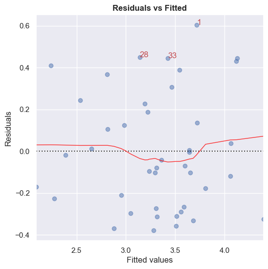

```python
import seaborn as sns

fig, ax = plt.subplots(1, figsize=(6, 6))
fitted = birthweight_mlr_full.fittedvalues
resid = birthweight_mlr_full.resid
sns.residplot(
    x=fitted,
    y=resid,
    lowess=True,
    scatter_kws={'alpha': 0.5},
    line_kws={'color': 'red', 'lw': 1, 'alpha': 0.8},
    ax=ax)

# annotations
residual_abs = np.abs(resid)
abs_resid = np.flip(np.argsort(residual_abs), 0)
abs_resid_top_3 = abs_resid[:3]
for i in abs_resid_top_3:
    ax.annotate(
        i,
        xy=(fitted[i], resid[i]),
        color='C3')

ax.set_title('Residuals vs Fitted', fontweight="bold")
ax.set_xlabel('Fitted values')
ax.set_ylabel('Residuals')
```

The points on the plot are randomly scattered around the zero line, so we conclude that the constant variance assumption is satisfied.

We continue by checking the normality assumption:

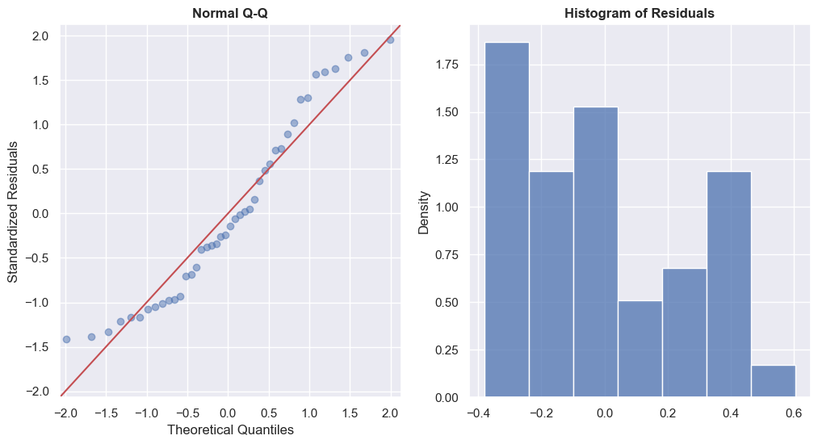

```python
fig, ax = plt.subplots(1, 2, figsize=(12, 6))

residual_norm = influence.resid_studentized_internal
QQ = ProbPlot(residual_norm)
fig = QQ.qqplot(line='45', alpha=0.5, lw=1, ax=ax[0])

sns.histplot(resid, stat='density', ax=ax[1]);

ax[0].set_title('Normal Q-Q', fontweight="bold")
ax[0].set_xlabel('Theoretical Quantiles')
ax[0].set_ylabel('Standardized Residuals');

ax[1].set_title('Histogram of Residuals', fontweight="bold")
```

We seem to have some departures from the normality assumption in this case.

### Collinearity: Car Seat Position Data (`seatpos`)

Car designers would find it helpful to know how different drivers will position the seat depending on their *size* and *age.* Researchers at the HuMoSim laboratory at the University of Michigan collected the following data on **38** drivers:

- `Age`: Drivers age in years
- `Weight`: Drivers weight in lbs
- `HtShoes`: height with shoes in cm
- `Ht`: height without shoes in cm
- `Seated`: seated height in cm
- `Arm`: lower arm length in cm
- `Thigh`: thigh length in cm
- `Leg`: lower leg length in cm
- `hipcenter`: horizontal distance of the midpoint of the hips from a fixed location in the car in mm

This dataset originates from the `faraway` R package and a `.csv` version can be downloaded from Julian Faraway's [Linear Models with Python repository](https://github.com/julianfaraway/LMP).

```python
seatpos = pd.read_csv("seatpos.csv")

# Fit the FULL model
var_names = [x for x in seatpos.columns if x != 'hipcenter']
fml_full = "hipcenter" + "~" + "+".join(x for x in var_names)
position_full = smf.ols(fml_full, data=seatpos).fit()
position_full.summary()
```

OLS Regression Results

| Dep. Variable: | hipcenter | R-squared: | 0.687 |
| --- | --- | --- | --- |
| Model: | OLS | Adj. R-squared: | 0.600 |
| Method: | Least Squares | F-statistic: | 7.940 |
| Date: | Tue, 02 Sep 2025 | Prob (F-statistic): | 1.31e-05 |
| Time: | 12:03:34 | Log-Likelihood: | -186.73 |
| No. Observations: | 38 | AIC: | 391.5 |
| Df Residuals: | 29 | BIC: | 406.2 |
| Df Model: | 8 |  |  |
| Covariance Type: | nonrobust |  |  |

|  | coef | std err | t | P>\|t\| | [0.025 | 0.975] |
| --- | --- | --- | --- | --- | --- | --- |
| Intercept | 436.4321 | 166.572 | 2.620 | 0.014 | 95.755 | 777.109 |
| Age | 0.7757 | 0.570 | 1.360 | 0.184 | -0.391 | 1.942 |
| Weight | 0.0263 | 0.331 | 0.080 | 0.937 | -0.651 | 0.703 |
| HtShoes | -2.6924 | 9.753 | -0.276 | 0.784 | -22.640 | 17.255 |
| Ht | 0.6013 | 10.130 | 0.059 | 0.953 | -20.117 | 21.319 |
| Seated | 0.5338 | 3.762 | 0.142 | 0.888 | -7.160 | 8.228 |
| Arm | -1.3281 | 3.900 | -0.341 | 0.736 | -9.305 | 6.649 |
| Thigh | -1.1431 | 2.660 | -0.430 | 0.671 | -6.583 | 4.297 |
| Leg | -6.4390 | 4.714 | -1.366 | 0.182 | -16.080 | 3.202 |

| Omnibus: | 0.543 | Durbin-Watson: | 1.769 |
| --- | --- | --- | --- |
| Prob(Omnibus): | 0.762 | Jarque-Bera (JB): | 0.664 |
| Skew: | 0.157 | Prob(JB): | 0.717 |
| Kurtosis: | 2.434 | Cond. No. | 8.44e+03 |

Notes:  
[1] Standard Errors assume that the covariance matrix of the errors is correctly specified.  
[2] The condition number is large, 8.44e+03. This might indicate that there are  
strong multicollinearity or other numerical problems.

Note that the $p$-value of the overall $F$ test is very small (`1.31e-05`), which means that *at least one of the predictors is statistically significant*, but at the same time none of the predictors is statistically significant according to the individual $t$ tests. This is strange and definitely a *red flag* that we may have collinearity issues.

To investigate the presence of high correlated predictors as well as the linear correlation of the response with each of the predictors, we start by checking the **correlation matrix**:

```python
seatpos.corr().round(2)
```

|  | Age | Weight | HtShoes | Ht | Seated | Arm | Thigh | Leg | hipcenter |
| --- | --- | --- | --- | --- | --- | --- | --- | --- | --- |
| Age | 1.00 | 0.08 | -0.08 | -0.09 | -0.17 | 0.36 | 0.09 | -0.04 | 0.21 |
| Weight | 0.08 | 1.00 | 0.83 | 0.83 | 0.78 | 0.70 | 0.57 | 0.78 | -0.64 |
| HtShoes | -0.08 | 0.83 | 1.00 | 1.00 | 0.93 | 0.75 | 0.72 | 0.91 | -0.80 |
| Ht | -0.09 | 0.83 | 1.00 | 1.00 | 0.93 | 0.75 | 0.73 | 0.91 | -0.80 |
| Seated | -0.17 | 0.78 | 0.93 | 0.93 | 1.00 | 0.63 | 0.61 | 0.81 | -0.73 |
| Arm | 0.36 | 0.70 | 0.75 | 0.75 | 0.63 | 1.00 | 0.67 | 0.75 | -0.59 |
| Thigh | 0.09 | 0.57 | 0.72 | 0.73 | 0.61 | 0.67 | 1.00 | 0.65 | -0.59 |
| Leg | -0.04 | 0.78 | 0.91 | 0.91 | 0.81 | 0.75 | 0.65 | 1.00 | -0.79 |
| hipcenter | 0.21 | -0.64 | -0.80 | -0.80 | -0.73 | -0.59 | -0.59 | -0.79 | 1.00 |

We observe that the response is *highly correlated with most of the variables* which justifies the low $p$-value in the overall $F$ test. However, we have **highly correlated predictors** (e.g. Corr(`Leg`, `HtShoes`)=0.91) which means that we will have *collinearity.*

Let's look at the **condition number** of the $\mathbf{X}^T\mathbf{X}$ matrix. Recall that the condition number is *not scale invariant*. This implies that calculating it before standardizing the matrix might lead to incorrect conclusions. So, let's standardize it first:

```python
# Extract the design matrix and remove the column of 1s that corresponds to the intercept.
X = position_full.model.exog[:, 1:]

# Standardize the matrix
scaler = StandardScaler()
X = scaler.fit_transform(X)

# show the variance
X.var(axis=0, ddof=0)
```

```
array([1., 1., 1., 1., 1., 1., 1., 1.])
```

Compute the condition number using the standardized matrix:

```python
# Compute the eigenvalues of the correlation matrix (X^T*X for standardized data)
eigenvalues, _ = np.linalg.eig(X.T @ X)

print("Eigenvalues of the correlation matrix:")
print(np.sort(eigenvalues)[::-1])

# Compute the condition number:
condition_number = np.sqrt(eigenvalues.max() / eigenvalues.min())
print(f"Condition Number: {condition_number:.4f}")
```

```
Eigenvalues of the correlation matrix:
[2.15581055e+02 4.69978684e+01 1.76222508e+01 9.15641723e+00
 7.38034342e+00 5.28861961e+00 1.91309203e+00 6.03530674e-02]
Condition Number: 59.7662
```

The condition number is **59.77**, larger than 30, so we conclude that *collinearity is present*.

Let's also check the **Variance Inflation Factor (VIF)**:

```python
variance_inflation_factor(X, 1)
```

```
np.float64(3.647030128812388)
```

```python
p = X.shape[1]
vif_data = np.array([variance_inflation_factor(X, i) for i in range(p)])
display(vif_data)

np.sqrt(307.43)
```

```
array([  1.99793148,   3.64703013, 307.42937802, 333.13783239,
         8.9510538 ,   4.49636844,   2.76288552,   6.69429122])
```

```
np.float64(17.5336818723279)
```

Note that the *standard error* for the coefficient associated with `HtShoes` is **17.53 times larger** than it would have been without collinearity.

The next step is to **investigate which variable to remove**. To do so, we study the *pairwise correlations* and perform *partial $F$-tests* as follows:

```python
position_red1 = smf.ols(
    'hipcenter ~ Age + Weight + Ht + Seated', data=seatpos).fit()

position_red1.summary()
```

OLS Regression Results

| Dep. Variable: | hipcenter | R-squared: | 0.660 |
| --- | --- | --- | --- |
| Model: | OLS | Adj. R-squared: | 0.619 |
| Method: | Least Squares | F-statistic: | 16.01 |
| Date: | Tue, 02 Sep 2025 | Prob (F-statistic): | 2.22e-07 |
| Time: | 12:03:49 | Log-Likelihood: | -188.28 |
| No. Observations: | 38 | AIC: | 386.6 |
| Df Residuals: | 33 | BIC: | 394.8 |
| Df Model: | 4 |  |  |
| Covariance Type: | nonrobust |  |  |

|  | coef | std err | t | P>\|t\| | [0.025 | 0.975] |
| --- | --- | --- | --- | --- | --- | --- |
| Intercept | 478.6589 | 159.734 | 2.997 | 0.005 | 153.678 | 803.639 |
| Age | 0.5840 | 0.426 | 1.372 | 0.179 | -0.282 | 1.450 |
| Weight | -0.0154 | 0.316 | -0.049 | 0.962 | -0.659 | 0.628 |
| Ht | -4.9902 | 1.644 | -3.036 | 0.005 | -8.335 | -1.646 |
| Seated | 2.0463 | 3.413 | 0.600 | 0.553 | -4.897 | 8.990 |

| Omnibus: | 0.512 | Durbin-Watson: | 1.672 |
| --- | --- | --- | --- |
| Prob(Omnibus): | 0.774 | Jarque-Bera (JB): | 0.435 |
| Skew: | -0.244 | Prob(JB): | 0.805 |
| Kurtosis: | 2.810 | Cond. No. | 6.70e+03 |

Notes:  
[1] Standard Errors assume that the covariance matrix of the errors is correctly specified.  
[2] The condition number is large, 6.7e+03. This might indicate that there are  
strong multicollinearity or other numerical problems.

```python
position_red2 = smf.ols('hipcenter ~ Ht', data=seatpos).fit()
display(position_red2.summary())
```

OLS Regression Results

| Dep. Variable: | hipcenter | R-squared: | 0.638 |
| --- | --- | --- | --- |
| Model: | OLS | Adj. R-squared: | 0.628 |
| Method: | Least Squares | F-statistic: | 63.53 |
| Date: | Tue, 02 Sep 2025 | Prob (F-statistic): | 1.83e-09 |
| Time: | 12:03:52 | Log-Likelihood: | -189.45 |
| No. Observations: | 38 | AIC: | 382.9 |
| Df Residuals: | 36 | BIC: | 386.2 |
| Df Model: | 1 |  |  |
| Covariance Type: | nonrobust |  |  |

|  | coef | std err | t | P>\|t\| | [0.025 | 0.975] |
| --- | --- | --- | --- | --- | --- | --- |
| Intercept | 556.2553 | 90.670 | 6.135 | 0.000 | 372.367 | 740.144 |
| Ht | -4.2650 | 0.535 | -7.970 | 0.000 | -5.350 | -3.180 |

| Omnibus: | 1.707 | Durbin-Watson: | 1.890 |
| --- | --- | --- | --- |
| Prob(Omnibus): | 0.426 | Jarque-Bera (JB): | 1.028 |
| Skew: | -0.395 | Prob(JB): | 0.598 |
| Kurtosis: | 3.154 | Cond. No. | 2.60e+03 |

Notes:  
[1] Standard Errors assume that the covariance matrix of the errors is correctly specified.  
[2] The condition number is large, 2.6e+03. This might indicate that there are  
strong multicollinearity or other numerical problems.

```python
anova_seatpos = sm.stats.anova_lm(position_red2, position_red1)
anova_seatpos
```

|  | df_resid | ssr | df_diff | ss_diff | F | Pr(>F) |
| --- | --- | --- | --- | --- | --- | --- |
| 0 | 36.0 | 47615.793248 | 0.0 | NaN | NaN | NaN |
| 1 | 33.0 | 44774.245915 | 3.0 | 2841.547333 | 0.698103 | 0.559892 |

Based on the $F$ test provided in the ANOVA table, we conclude that the reduced model with `Ht` as the only variable is better than the model that includes `Age`, `Weight`, `Ht` and `Seated`.